# Project: The Medical Appointment No Shows Dataset

- Introduction
- Data Wrangling
- Exploratory Data Analysis
- Conclusions

## Introduction

#### Dataset Overview

This dataset contains some information of some patients' medical appointments and weither or not they show to their appointment.

This information is:

The IDs of the patient and the appointment.

The gendre and age of the patient.

The scheduled date and the appointment day.

Some characteristics and problems of the patients like their Scholarship(social welfare program) and weither or not they have Hypertension,Diabetes and Alcoholism and the number of Handicaps they have if any.

Weither the patient recived an SMS or not.

The location of the hospital.

#### Exploring the Dataset

```python
#importing necessary packages
import numpy as np
import pandas as pd
import matplotlib.pyplot as plt
%matplotlib inline
```

```python
#reading dataset
df = pd.read_csv('dataset.csv')
```

```python
#exploring the dataset
df.head()
```

|  | PatientId | AppointmentID | Gender | ScheduledDay | AppointmentDay | Age | Neighbourhood | Scholarship | Hipertension | Diabetes | Alcoholism | Handcap | SMS_received | No-show |
| --- | --- | --- | --- | --- | --- | --- | --- | --- | --- | --- | --- | --- | --- | --- |
| 0 | 2.987250e+13 | 5642903 | F | 2016-04-29T18:38:08Z | 2016-04-29T00:00:00Z | 62 | JARDIM DA PENHA | 0 | 1 | 0 | 0 | 0 | 0 | No |
| 1 | 5.589978e+14 | 5642503 | M | 2016-04-29T16:08:27Z | 2016-04-29T00:00:00Z | 56 | JARDIM DA PENHA | 0 | 0 | 0 | 0 | 0 | 0 | No |
| 2 | 4.262962e+12 | 5642549 | F | 2016-04-29T16:19:04Z | 2016-04-29T00:00:00Z | 62 | MATA DA PRAIA | 0 | 0 | 0 | 0 | 0 | 0 | No |
| 3 | 8.679512e+11 | 5642828 | F | 2016-04-29T17:29:31Z | 2016-04-29T00:00:00Z | 8 | PONTAL DE CAMBURI | 0 | 0 | 0 | 0 | 0 | 0 | No |
| 4 | 8.841186e+12 | 5642494 | F | 2016-04-29T16:07:23Z | 2016-04-29T00:00:00Z | 56 | JARDIM DA PENHA | 0 | 1 | 1 | 0 | 0 | 0 | No |

```python
df.shape
```

```
(110527, 14)
```

```python
df.describe()
```

|  | PatientId | AppointmentID | Age | Scholarship | Hipertension | Diabetes | Alcoholism | Handcap | SMS_received |
| --- | --- | --- | --- | --- | --- | --- | --- | --- | --- |
| count | 1.105270e+05 | 1.105270e+05 | 110527.000000 | 110527.000000 | 110527.000000 | 110527.000000 | 110527.000000 | 110527.000000 | 110527.000000 |
| mean | 1.474963e+14 | 5.675305e+06 | 37.088874 | 0.098266 | 0.197246 | 0.071865 | 0.030400 | 0.022248 | 0.321026 |
| std | 2.560949e+14 | 7.129575e+04 | 23.110205 | 0.297675 | 0.397921 | 0.258265 | 0.171686 | 0.161543 | 0.466873 |
| min | 3.921784e+04 | 5.030230e+06 | -1.000000 | 0.000000 | 0.000000 | 0.000000 | 0.000000 | 0.000000 | 0.000000 |
| 25% | 4.172614e+12 | 5.640286e+06 | 18.000000 | 0.000000 | 0.000000 | 0.000000 | 0.000000 | 0.000000 | 0.000000 |
| 50% | 3.173184e+13 | 5.680573e+06 | 37.000000 | 0.000000 | 0.000000 | 0.000000 | 0.000000 | 0.000000 | 0.000000 |
| 75% | 9.439172e+13 | 5.725524e+06 | 55.000000 | 0.000000 | 0.000000 | 0.000000 | 0.000000 | 0.000000 | 1.000000 |
| max | 9.999816e+14 | 5.790484e+06 | 115.000000 | 1.000000 | 1.000000 | 1.000000 | 1.000000 | 4.000000 | 1.000000 |

#### Things we should notice about the dataset

Very few patients have Handicaps and Alcoholism while more but still few have Hipertension,Diabetes.

The '-1' value in the ages column which (according to the dataset creator) considered babies that are not born yet (pregnant woman) so this is not a problem to be bothered with.

Few people particapted in the Bolsa Família scholarship.

#### Asking questions about the dataset

1. Is there a relation between the age or the gendre of the patient and him showing to the appointment?
2. Does any of the characteristics and problems of the patients like Hypertension affect showing to the appointment? Does receiving an sms matter?
3. Does the delay between the appointment and the schedule day and the weekday of the appointment affect showing to the appointment?

## Data Wrangling

#### Checking for duplicates

```python
df.duplicated().any()
```

```
False
```

#### Let's drop the columns that we don't need which are the IDs of the patient and appointment and the Neighbourhood .

```python
#dropping useless columns
df.drop(columns=['PatientId','AppointmentID','Neighbourhood'],inplace=True)
```

#### Then let's change the encoding of the 'No-show' column such that it's renamed as 'show' to be able to easily analyze it.

```python
#checking the contents of No-show column
df['No-show'].value_counts()
```

```
No     88208
Yes    22319
Name: No-show, dtype: int64
```

```python
#transformin No-show column into (show) instead so that it can be easly analyzed)
df=df.rename(columns={"No-show": "show"})
df.loc[df.show == 'No','show'] = 1
df.loc[df.show == 'Yes','show'] = 0
df.show=df.show.astype('int')  #making sure that the type is integer
```

```python
#rechecking the No-show column after transforming it to show
df.show.value_counts()
```

```
1    88208
0    22319
Name: show, dtype: int64
```

#### Checking the datatypes and null values.

```python
df.info()
```

```
<class 'pandas.core.frame.DataFrame'>
RangeIndex: 110527 entries, 0 to 110526
Data columns (total 11 columns):
 #   Column          Non-Null Count   Dtype
---  ------          --------------   -----
 0   Gender          110527 non-null  object
 1   ScheduledDay    110527 non-null  object
 2   AppointmentDay  110527 non-null  object
 3   Age             110527 non-null  int64
 4   Scholarship     110527 non-null  int64
 5   Hipertension    110527 non-null  int64
 6   Diabetes        110527 non-null  int64
 7   Alcoholism      110527 non-null  int64
 8   Handcap         110527 non-null  int64
 9   SMS_received    110527 non-null  int64
 10  show            110527 non-null  int32
dtypes: int32(1), int64(7), object(3)
memory usage: 8.9+ MB
```

#### we can see that all data types are good for now and no null values to be dealt with.

#### Extracting useful information from the 'AppointmentDay' and 'ScheduledDay' columns to answer the third question such that we obtain two new columns one for the delay time from scheduling to the appointment and the the other for the weekday of the appointment.

```python
week_day_dict = { 0:'Monday', 1:'Tuesday', 2:'Wednesday', 3:'Thursday', 4:'Friday', 5:'Saturday', 6:'Sunday' }
app_date =pd.to_datetime(df.AppointmentDay)
sch_date =pd.to_datetime(df.ScheduledDay)
waiting_time = (app_date-sch_date)
waiting_time_in_days= waiting_time.apply(lambda x:x.days+1) #one day was added to the waiting days to gurantee that if day of appointment is the same as the scheduled day then the patient waited for zero days as timing in hours of appointment day is always set to 0
app_week_day = app_date.apply(lambda x:week_day_dict[x.weekday()])
```

#### Having a look at the weekday data.

```python
app_week_day.value_counts()
```

```
Wednesday    25867
Tuesday      25640
Monday       22715
Friday       19019
Thursday     17247
Saturday        39
Name: AppointmentDay, dtype: int64
```

#### We can see that there were almost no recordings of data in weekends.

#### Now let's have a look at the waiting time data.

```python
waiting_time_in_days.describe()
```

```
count    110527.000000
mean         10.183702
std          15.254996
min          -6.000000
25%           0.000000
50%           4.000000
75%          15.000000
max         179.000000
dtype: float64
```

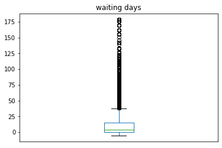

```python
waiting_time_in_days.plot(kind='box')
plt.xticks([]);
plt.title('waiting days');
```

#### We can see that there is a problem with outliers but we can leave them for now so that we can make use of the data of other columns before removing those problems.

#### As for the negative waiting time problem

```python
(waiting_time_in_days<0).value_counts()
```

```
False    110522
True          5
dtype: int64
```

#### we can see that these are few samples so it's ok to drop them

```python
df.drop(df[waiting_time_in_days<0].index,inplace=True)
```

#### Removing the 'ScheduledDay','AppointmentDay' columns as we don't need them now and adding 2 new columns 'waiting_days', 'week_day'.

```python
df.drop(columns=['ScheduledDay','AppointmentDay'],inplace=True)
df.insert(3, "waiting_days", waiting_time_in_days, True)
df.insert(4, "week_day",app_week_day, True)
```

#### Now that the dataframe is ready for the analysis let's have a look at it

```python
df.head()
```

|  | Gender | Age | Scholarship | waiting_days | week_day | Hipertension | Diabetes | Alcoholism | Handcap | SMS_received | show |
| --- | --- | --- | --- | --- | --- | --- | --- | --- | --- | --- | --- |
| 0 | F | 62 | 0 | 0 | Friday | 1 | 0 | 0 | 0 | 0 | 1 |
| 1 | M | 56 | 0 | 0 | Friday | 0 | 0 | 0 | 0 | 0 | 1 |
| 2 | F | 62 | 0 | 0 | Friday | 0 | 0 | 0 | 0 | 0 | 1 |
| 3 | F | 8 | 0 | 0 | Friday | 0 | 0 | 0 | 0 | 0 | 1 |
| 4 | F | 56 | 0 | 0 | Friday | 1 | 1 | 0 | 0 | 0 | 1 |

## Exploratory Data Analysis

### 1. Is there a relation between the age or the gendre of the patient and him showing to the appointment?

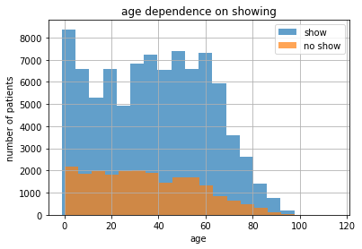

```python
#age dependence on showing
show = df.show == 1
no_show = df.show == 0
df.Age[show].hist(alpha=0.7 ,bins=20,label ='show')
df.Age[no_show].hist(alpha=0.7 ,bins=20,label ='no show')
plt.legend();
plt.title('age dependence on showing');
plt.xlabel('age');
plt.ylabel('number of patients')
```

```python
print('age (show) \n',df.Age[show].describe(),'\n\nage (no show) \n',df.Age[no_show].describe())
```

```
age (show)
 count    88208.000000
mean        37.790064
std         23.338878
min         -1.000000
25%         18.000000
50%         38.000000
75%         56.000000
max        115.000000
Name: Age, dtype: float64

age (no show)
 count    22314.000000
mean        34.317872
std         21.965009
min          0.000000
25%         16.000000
50%         33.000000
75%         51.000000
max        115.000000
Name: Age, dtype: float64
```

#### Now for the gendre:

let's first define a pie plotting function to be able to use it for other questions.

```python
def pie_plot(srs,labels):
    srs[show].value_counts().plot(kind='pie',label='',autopct=lambda pct: "{:.1f}%".format(pct),textprops=dict(color="w"),labels=labels,fontsize=12,style='bold');#,figsize=(5,5));
    plt.title('show',fontdict={'fontsize':14})
    plt.legend();
    plt.show();
    srs[no_show].value_counts().plot(kind='pie',label='',autopct=lambda pct: "{:.1f}%".format(pct),textprops=dict(color="w"),labels=labels,fontsize=12,style='bold');#,figsize=(5,5));
    plt.legend();
    plt.title('no show',fontdict={'fontsize':14})
```

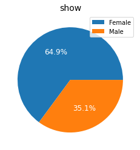

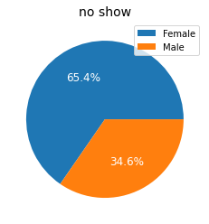

```python
labels = ['Female','Male']
pie_plot(df.Gender,labels)
```

```python
print('Gendre (show) \n',df.Gender[show].value_counts(),'\n\nGendre (no show) \n',df.Gender[no_show].value_counts())
```

```
Gendre (show)
 F    57246
M    30962
Name: Gender, dtype: int64

Gendre (no show)
 F    14591
M     7723
Name: Gender, dtype: int64
```

#### We notice that the Gendre distribution is almost the same so it doesn't have a relation to showing.

### Does any of the characteristics and problems of the patients like Hypertension affect showing to the appointment? Does receiving an sms matter?

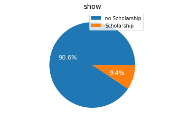

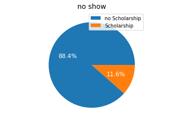

```python
labels = ['no Scholarship','Scholarship']
pie_plot(df.Scholarship,labels)
```

#### From the distribution we see that people that participate in the Bolsa Família scholarship tend by a little bit to not show to the appointment.

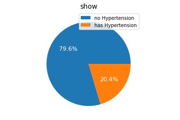

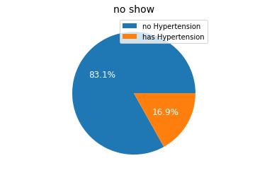

```python
labels = ['no Hypertension','has Hypertension']
pie_plot(df.Hipertension,labels)
```

#### From the distribution we see that people with Hypertension tend by a little bit to show to the appointment.

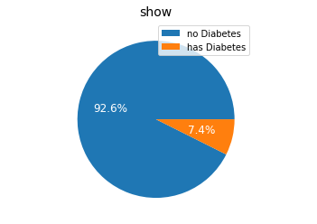

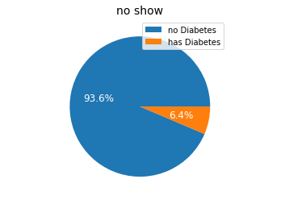

```python
labels = ['no Diabetes','has Diabetes']
pie_plot(df.Diabetes,labels)
```

#### From the graph we see that the distribution of having Diabetes is almost the same for the two cases of showing and not showing so having diabetes won't tell us much.

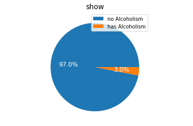

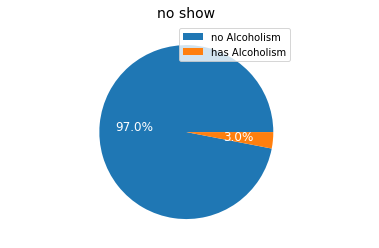

```python
labels = ['no Alcoholism','has Alcoholism']
pie_plot(df.Alcoholism,labels)
```

#### From the graph we see that the distribution of having Alcoholism is almost the same for the two cases of showing and not showing so it won't tell us much as wel.

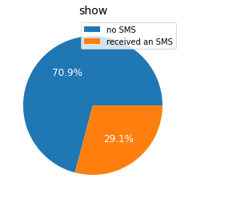

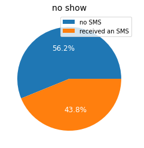

```python
labels = ['no SMS','received an SMS']
pie_plot(df.SMS_received,labels)
```

#### From the graph we see that people who recieve an sms tend to not show their appointments much more .

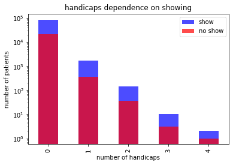

```python
df.Handcap[show].value_counts().plot(kind='bar',color='blue',alpha=0.7,label='show');
df.Handcap[no_show].value_counts().plot(kind='bar',color='red',alpha=0.7,label='no show');
plt.yscale('log')
plt.legend();
plt.title('handicaps dependence on showing');
plt.xlabel('number of handicaps');
plt.ylabel('number of patients');
```

The ratio between the people that show relative to people that does't show can be easily represented by the area of the visible part of the blue rectangle (as the y axis is logsclae) then it represents the log of this ratio. The areas of all blue visible rectangles are equal which is why the distribution of showing is the same except for having 4 handicaps but the number of people having very small so we can't conclude much from here.

```python
print('Handicap (show) \n',df.Handcap[show].value_counts(),'\n\nHandicap (no show) \n',df.Handcap[no_show].value_counts())
```

```
Handicap (show)
 0    86374
1     1676
2      146
3       10
4        2
Name: Handcap, dtype: int64

Handicap (no show)
 0    21909
1      364
2       37
3        3
4        1
Name: Handcap, dtype: int64
```

#### The distribution of showing for the number of handicaps is almost the same so that doesn't have a relation to showing.

### Does the delay between the appointment and the schedule day and the weekday of the appointment affect showing to the appointment?

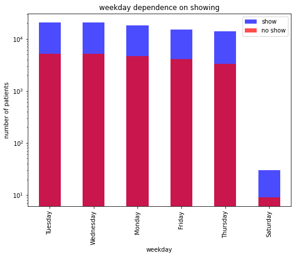

```python
df.week_day[show].value_counts().plot(kind='bar',color='blue',alpha=0.7,label='show',figsize=(8,6));
df.week_day[no_show].value_counts().plot(kind='bar',color='red',alpha=0.7,label='no show');
plt.yscale('log')
plt.legend();
plt.title('weekday dependence on showing');
plt.xlabel('weekday');
plt.ylabel('number of patients');
```

We also find the areas of all visible parts of blue squares are equal which is why the distribution of showing is the same for weekdays.

```python
print('weekday (show) \n',df.week_day[show].value_counts(),'\n\nweekday (no show) \n',df.week_day[no_show].value_counts())
```

```
weekday (show)
 Wednesday    20774
Tuesday      20488
Monday       18025
Friday       14982
Thursday     13909
Saturday        30
Name: week_day, dtype: int64

weekday (no show)
 Tuesday      5150
Wednesday    5092
Monday       4689
Friday       4037
Thursday     3337
Saturday        9
Name: week_day, dtype: int64
```

#### The distribution of showing for different weekdays is almost the same so that doesn't have a relation to showing as well.

```python
#removing outliers for the waiting days column
no_outliers = df.waiting_days < 50
df1 = df[no_outliers]
```

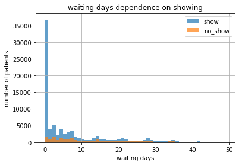

```python
df1.waiting_days[show].hist(alpha=0.7 ,bins=50,label ='show')
df1.waiting_days[no_show].hist(alpha=0.7,bins=50 ,label ='no_show')
plt.legend();
plt.title('waiting days dependence on showing');
plt.xlabel('waiting days');
plt.ylabel('number of patients');
```

#### From the distribution of waiting days we see that if the day of the appointment is the same as the day of scheduling people strongly tend to show more to their appointments.¶

## Conclusions

This notebook provides an analysis to 'the Medical Appointment No Shows' dataset to know which of the features of the patients and their appointments has a large effect on people showing/not-showing to their scheduled appointments. And as shown from the figures and analysis these strongest effective features are age,receiving an sms and the number of waiting days.

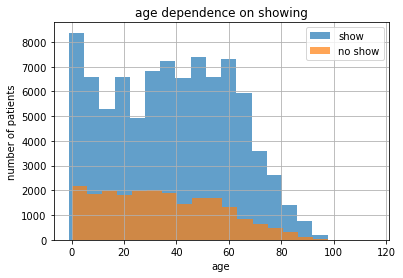

```python
df.Age[show].hist(alpha=0.7 ,bins=20,label ='show')
df.Age[no_show].hist(alpha=0.7 ,bins=20,label ='no show')
plt.legend();
plt.title('age dependence on showing');
plt.xlabel('age');
plt.ylabel('number of patients');
```

People that recieve an sms tend to not show their appointments much more.

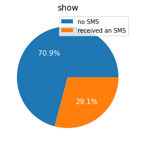

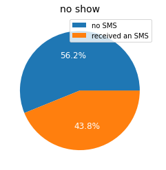

```python
labels = ['no SMS','received an SMS']
pie_plot(df.SMS_received,labels)
```

Patients that wait less than one day strongly tend to show more to their appointments.

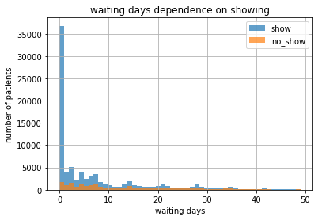

```python
df1.waiting_days[show].hist(alpha=0.7 ,bins=50,label ='show')
df1.waiting_days[no_show].hist(alpha=0.7,bins=50 ,label ='no_show')
plt.legend();
plt.title('waiting days dependence on showing');
plt.xlabel('waiting days');
plt.ylabel('number of patients');
```

### Limitations

Giving some info about some patients and tring to predict if they show to their appointments we need to attach every thing together first so it's better to use a machine learning technique to have good predictions.